# Day 1

# 1 Preliminaries

Set the **working directory** to its location. In RStudio,

````
 ```
 Session > Set Working Directory > To Source File Location
 ```
````

## 1.1 - Use the `install.packages` function to install the `performance`, `see`, `GGally`, `lmerTest`, `psych`, `sandwich`, `lmtest`, `tidyverse`, and `brms` packages.

```r
# Install the packages
install.packages(
     pkgs = c("performance", "see", "GGally", "lmerTest", "psych", "sandwich", "lmtest", "tidyverse", "brms"),
     repos = "http://cloud.r-project.org"
)
```

## 1.2 - Use the `library` function to load the packages.

```r
# Load the packages
library(performance)
library(see)
library(GGally)
library(lmerTest)
library(psych)
library(sandwich)
library(lmtest)
library(tidyverse)
library(brms)
```

## 1.3 - Use the `load` function to load the `PracticalDay1.RData` environment into your workspace.

```r
load("PracticalDay1.RData")
```

# 2 Part 1: Visualization & Modeling

These assignments are about a study on the popularity of highschool students. A total of 246 students from 12 different classes took part in this study in which we determined how extraversion, gender, and teacher experience influenced a student’s popularity.

The data for the 12 different classes are stored in de the dataframes Class1 - Class12. The dataframe Total contains the combined data of all classes.

List of all the variables:

- `pupil`: pupil identification variable
- `class`: class identification variable
- student-level independent variables: `Extraversion` (continuous; higher scores mean higher extraversion) and `Gender` (dichotomous; 0 = `male`, 1 = `female`)
- class-level independent variables: teacher experience `teacherExp` in years
- outcome variable: `Popular` (continuous: higher scores indicate higher popularity).

## 2.1 - Assignment 1: Inspection

Let’s look at descriptives, visualize our data, and check assumptions for relevant variables. For simplicity, we’ll only look at the variables Extraversion, Popular, and Gender (but feel free to play around with the other variables too). We’ll first select only those variables and store them in a dataframe called subset which we’ll run our visualization on.

- Check the datatype of all variables and see if they are correct. Which variable do you need to change?
- Check distributions and scatterlots of the relevant variables. Do they look okay?
- Run an initial linear model with `Popular` as the DV and `Extraversion` and `Gender` as the IVs, and check the model using the `check_model` command (note that we don’t look at model parameters yet, since we do not yet know if this model is really appropriate). Note that we can get more information about influential cases and outliers by asking for this info explicitly using `$INFLUENTIAL` and `$OUTLIERS` after the `check_model` output object. Do we have to account for heteroscedasticity?
- Also check model assumptions when Extraversion is entered as an ordinal variable. Do the diagnostics improve?

### 2.1.1 - Subsetting

```r
head(Total) # shows first lines of data
```

```
  Pupil Class Extraversion Gender teacherExp Popular      TEc
1     1     1  -0.07723577      1         24     6.3 9.833333
2     2     1   1.92276423      0         24     4.9 9.833333
3     3     1  -1.07723577      1         24     5.3 9.833333
4     4     1  -2.07723577      1         24     4.7 9.833333
5     5     1  -0.07723577      1         24     6.0 9.833333
6     6     1  -1.07723577      0         24     4.7 9.833333
```

```r
describe(Total, fast = TRUE) # descriptive statistics for all variables
```

```
             vars   n  mean   sd   min   max range   se
Pupil           1 246 10.83 6.07  1.00 24.00  23.0 0.39
Class           2 246  6.52 3.41  1.00 12.00  11.0 0.22
Extraversion    3 246  0.00 1.11 -3.08  2.92   6.0 0.07
Gender          4 246  0.48 0.50  0.00  1.00   1.0 0.03
teacherExp      5 246 14.28 5.52  5.00 24.00  19.0 0.35
Popular         6 246  4.67 1.11  1.50  7.30   5.8 0.07
TEc             7 246  0.12 5.52 -9.17  9.83  19.0 0.35
```

```r
subset <- Total %>%
          select(Extraversion, Popular, Gender)

head(subset)
```

```
  Extraversion Popular Gender
1  -0.07723577     6.3      1
2   1.92276423     4.9      0
3  -1.07723577     5.3      1
4  -2.07723577     4.7      1
5  -0.07723577     6.0      1
6  -1.07723577     4.7      0
```

### 2.1.2 - Checking data types

```r
subset <- as_tibble(subset)
subset
```

```
# A tibble: 246 × 3
   Extraversion Popular Gender
          <dbl>   <dbl>  <int>
 1      -0.0772     6.3      1
 2       1.92       4.9      0
 3      -1.08       5.3      1
 4      -2.08       4.7      1
 5      -0.0772     6        1
 6      -1.08       4.7      0
 7      -0.0772     5.9      0
 8      -1.08       4.2      0
 9      -0.0772     5.2      0
10      -0.0772     3.9      0
# ℹ 236 more rows
```

Gender needs to be a factor and not an integer.

```r
subset$Gender <- factor(subset$Gender, labels = c("Male", "Female"))
```

### 2.1.3 - Check distribution and scatterplots

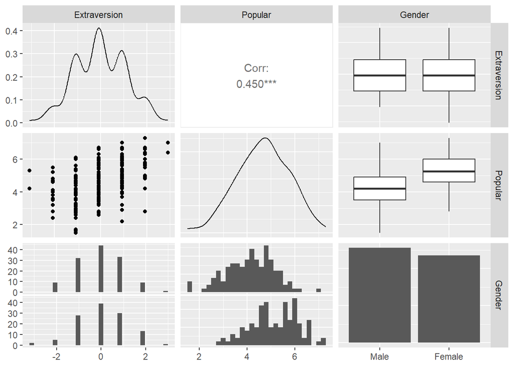

```r
ggpairs(subset)
```

Based on the visualization so far, a linear model seems like a good initial modeling choice (see the slides for a more thorough discussion of this).

### 2.1.4 - Run and check linear regression model

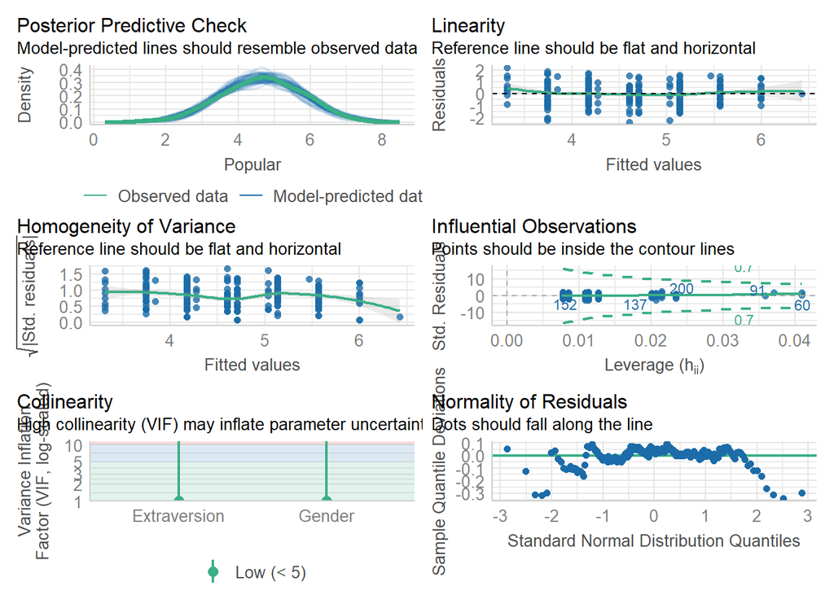

```r
Regr1 <- lm(Popular ~ 1 + Extraversion + Gender, data = Total)
viz_check <- check_model(Regr1)
viz_check
```

### 2.1.5 - Furhter inspecting influential observations and outliers

```r
viz_check$INFLUENTIAL
```

```
            Hat Cooks_Distance Predicted    Residuals Std_Residuals Index Influential
1   0.008528267   5.209512e-03  5.134279  1.165721066   1.347934961     1          OK
2   0.020690858   1.710504e-04  5.033949 -0.133948763  -0.155845140     2          OK
3   0.012695608   2.044745e-03  4.703940  0.596060120   0.690683360     3          OK
4   0.023508169   1.980715e-03  4.273601  0.426399174   0.496817070     4          OK
5   0.008528267   2.873186e-03  5.134279  0.865721066   1.001041952     5          OK
6   0.011346018   4.698383e-03  3.742932  0.957068399   1.108243718     6          OK
7   0.007815745   1.046025e-02  4.173271  1.726729345   1.995917406     7          OK
8   0.011346018   1.071581e-03  3.742932  0.457068399   0.529265393     8          OK
9   0.007815745   3.698327e-03  4.173271  1.026729345   1.186791072     9          OK
10  0.007815745   2.619868e-04  4.173271 -0.273270655  -0.315872118    10          OK
11  0.008528267   1.226909e-03  5.134279  0.565721066   0.654148943    11          OK
12  0.008528267   4.283766e-04  5.134279 -0.334278934  -0.386530084    12          OK
13  0.007815745   2.397839e-03  4.173271  0.826729345   0.955612120    13          OK
14  0.008528267   5.127524e-04  5.134279  0.365721066   0.422886937    14          OK
```

[output cut: 232 more lines]

```r
viz_check$OUTLIERS
```

```
OK: No outliers detected.
- Based on the following method and threshold: cook (0.8).
- For variable: (Whole model)
```

Here everything is ok. You can also store the check_model(Regr1) plot in a PDF to improve visualization.

```r
pdf("check_model.pdf")
check_model(Regr1)
dev.off()
```

### 2.1.6 - Model assumptions with `Extraversion` as ordinal variable

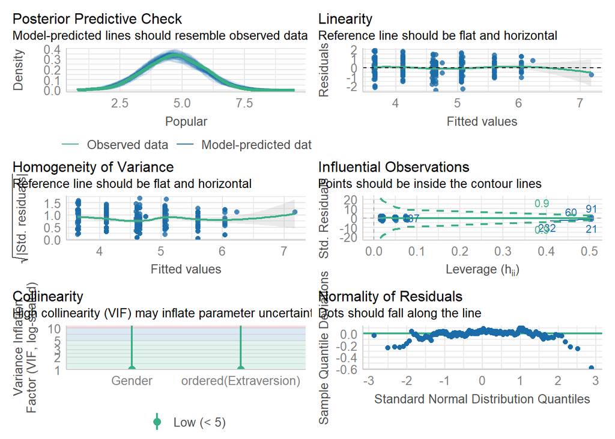

```r
Regr1_o <- lm(Popular ~ 1 + ordered(Extraversion) + Gender, data = Total)
check_model(Regr1_o)
```

We decide to go for the regression model with `Extraversion` as a continuous variable, because entering `Extraversion` as ordinal did not improve diagnostics much (see the lecture for more info). However, homogeneity was not great for this data. As such we might opt to use robust SEs using the `vcovHC` command. Using the HC covariance matrix `covHC0`, you can go ahead and investigate the coefficients of Regr1 with robust SEs.

### 2.1.7 - Accounting of heteroscedasticity

```r
covHC0 <- vcovHC(Regr1)
coeftest(Regr1, vcov = covHC0)
```

```
t test of coefficients:

             Estimate Std. Error t value  Pr(>|t|)
(Intercept)  4.206508   0.081890 51.3680 < 2.2e-16 ***
Extraversion 0.430339   0.053082  8.1070 2.551e-14 ***
Gender       0.961008   0.111005  8.6574 6.785e-16 ***
---
Signif. codes:  0 '***' 0.001 '**' 0.01 '*' 0.05 '.' 0.1 ' ' 1
```

## 2.2 - Assignment 2: Modeling Heteroscedasticity

We could also deal with the heteroscedasticity in our data by actually modeling it. This is easy to do with Bayesian analysis. Let’s assume that we expect based on visualization or prior knowledge that higher extraversion is associated with lower variability in popularity. In other words, the heterogeneity is based on `Extraversion`.

- Run a Bayesian analysis without correction for heteroscedasticity and compare the results to the frequentist results. Do the results differ?
- Run a Bayesian analysis, where you model the dependence of the residual variance, sigma, on `Extraversion`. Since you’re basically doing two regression analyses, one to predict the mean of `Popular` and one to predict the SD (or the variance sigma), you combine both the models in one object using the `bf` command. What is the effect of `Extraversion` on sigma? Do the parameter estimates differ compared to the frequentist results?

### 2.2.1 Bayesian versus frequentist results

```r
Regr1_Bayes <- brm(Popular ~ 1 + Extraversion + Gender, data = Total)
summary(Regr1_Bayes)
```

```
 Family: gaussian
  Links: mu = identity; sigma = identity
Formula: Popular ~ 1 + Extraversion + Gender
   Data: Total (Number of observations: 246)
  Draws: 4 chains, each with iter = 2000; warmup = 1000; thin = 1;
         total post-warmup draws = 4000

Population-Level Effects:
             Estimate Est.Error l-95% CI u-95% CI Rhat Bulk_ESS Tail_ESS
Intercept        4.21      0.08     4.06     4.36 1.00     5440     3156
Extraversion     0.43      0.05     0.33     0.53 1.00     4899     3255
Gender           0.96      0.11     0.75     1.18 1.00     4868     2834

Family Specific Parameters:
      Estimate Est.Error l-95% CI u-95% CI Rhat Bulk_ESS Tail_ESS
sigma     0.87      0.04     0.80     0.96 1.00     4869     2994

Draws were sampled using sampling(NUTS). For each parameter, Bulk_ESS
and Tail_ESS are effective sample size measures, and Rhat is the potential
scale reduction factor on split chains (at convergence, Rhat = 1).
```

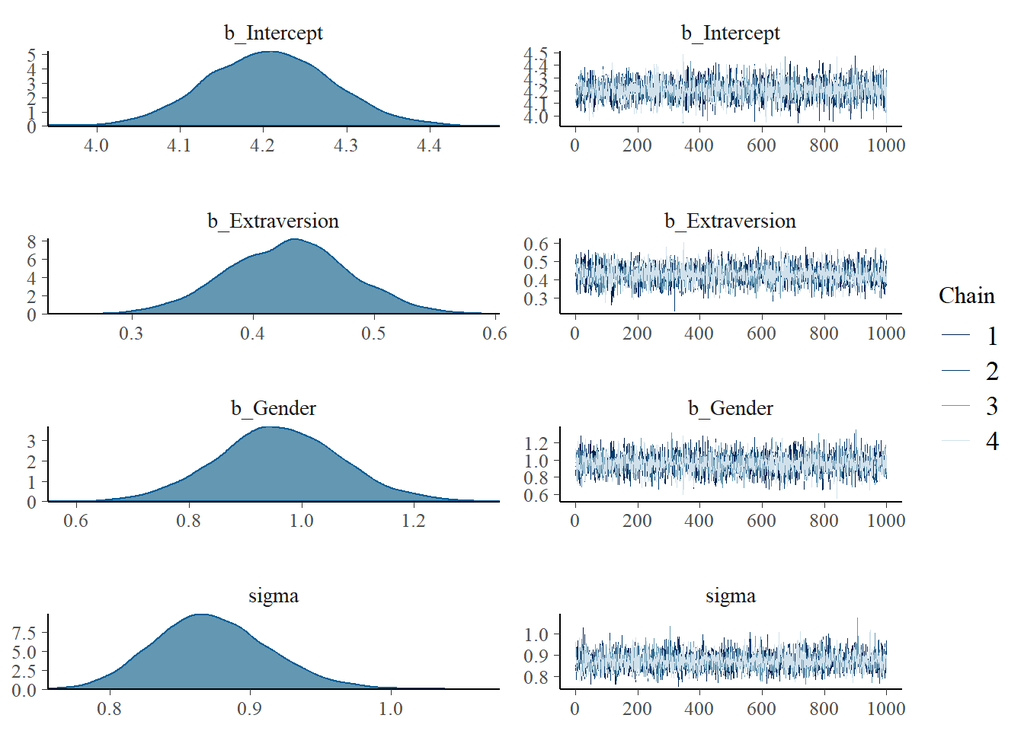

```r
plot(Regr1_Bayes)
```

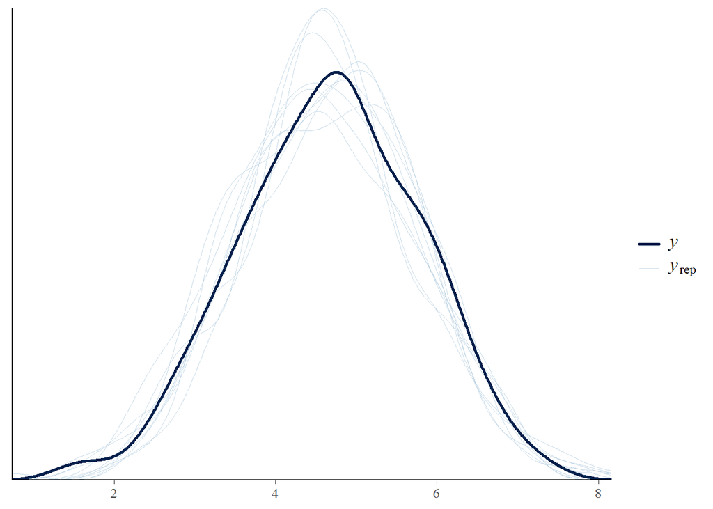

```r
pp_check(Regr1_Bayes)
```

```r
summary(Regr1)
```

```
Call:
lm(formula = Popular ~ 1 + Extraversion + Gender, data = Total)

Residuals:
     Min       1Q   Median       3Q      Max
-2.40361 -0.60386  0.02673  0.59606  2.18741

Coefficients:
             Estimate Std. Error t value Pr(>|t|)
(Intercept)   4.20651    0.07680  54.770  < 2e-16 ***
Extraversion  0.43034    0.05006   8.596 1.02e-15 ***
Gender        0.96101    0.11095   8.662 6.58e-16 ***
---
Signif. codes:  0 '***' 0.001 '**' 0.01 '*' 0.05 '.' 0.1 ' ' 1

Residual standard error: 0.8685 on 243 degrees of freedom
Multiple R-squared:  0.3904,    Adjusted R-squared:  0.3854
F-statistic: 77.82 on 2 and 243 DF,  p-value: < 2.2e-16
```

The results of the frequentist and Bayesian analyses without corrections are very similar, we can just take a more detailed look at results with the Bayesian analysis (create plots for parameters etc.)

### 2.2.2 Modeling heteroscedasticity with the Bayesian analysis

```r
het_mod <- bf(Popular ~ 1 + Extraversion + Gender, sigma ~ Extraversion)
Regr2_Bayes <- brm(het_mod, data = Total)
summary(Regr2_Bayes)
```

```
 Family: gaussian
  Links: mu = identity; sigma = log
Formula: Popular ~ 1 + Extraversion + Gender
         sigma ~ Extraversion
   Data: Total (Number of observations: 246)
  Draws: 4 chains, each with iter = 2000; warmup = 1000; thin = 1;
         total post-warmup draws = 4000

Population-Level Effects:
                   Estimate Est.Error l-95% CI u-95% CI Rhat Bulk_ESS Tail_ESS
Intercept              4.20      0.08     4.04     4.35 1.00     4885     2602
sigma_Intercept       -0.14      0.05    -0.23    -0.05 1.00     4741     2890
Extraversion           0.45      0.05     0.36     0.55 1.00     4144     3101
Gender                 0.98      0.11     0.77     1.19 1.00     5082     3165
sigma_Extraversion    -0.07      0.04    -0.15     0.01 1.00     4445     3016

Draws were sampled using sampling(NUTS). For each parameter, Bulk_ESS
and Tail_ESS are effective sample size measures, and Rhat is the potential
scale reduction factor on split chains (at convergence, Rhat = 1).
```

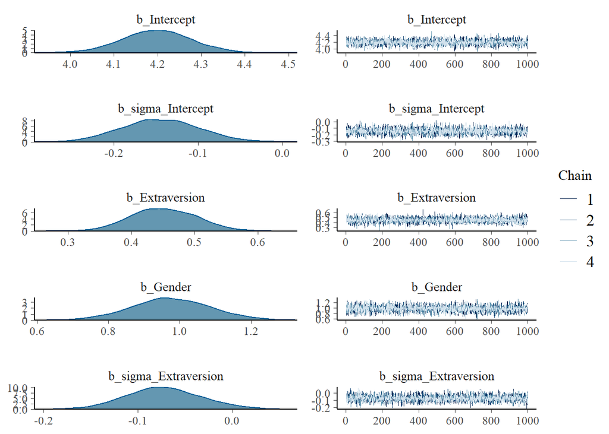

```r
plot(Regr2_Bayes)
```

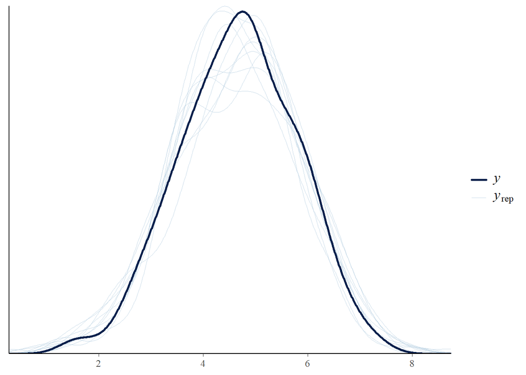

```r
pp_check(Regr2_Bayes)
```

We indeed see a negative effect of Extraverison on sigma (-0.07).

```r
coeftest(Regr1, vcov = covHC0)
```

```
t test of coefficients:

             Estimate Std. Error t value  Pr(>|t|)
(Intercept)  4.206508   0.081890 51.3680 < 2.2e-16 ***
Extraversion 0.430339   0.053082  8.1070 2.551e-14 ***
Gender       0.961008   0.111005  8.6574 6.785e-16 ***
---
Signif. codes:  0 '***' 0.001 '**' 0.01 '*' 0.05 '.' 0.1 ' ' 1
```

```r
summary(Regr2_Bayes)
```

```
 Family: gaussian
  Links: mu = identity; sigma = log
Formula: Popular ~ 1 + Extraversion + Gender
         sigma ~ Extraversion
   Data: Total (Number of observations: 246)
  Draws: 4 chains, each with iter = 2000; warmup = 1000; thin = 1;
         total post-warmup draws = 4000

Population-Level Effects:
                   Estimate Est.Error l-95% CI u-95% CI Rhat Bulk_ESS Tail_ESS
Intercept              4.20      0.08     4.04     4.35 1.00     4885     2602
sigma_Intercept       -0.14      0.05    -0.23    -0.05 1.00     4741     2890
Extraversion           0.45      0.05     0.36     0.55 1.00     4144     3101
Gender                 0.98      0.11     0.77     1.19 1.00     5082     3165
sigma_Extraversion    -0.07      0.04    -0.15     0.01 1.00     4445     3016

Draws were sampled using sampling(NUTS). For each parameter, Bulk_ESS
and Tail_ESS are effective sample size measures, and Rhat is the potential
scale reduction factor on split chains (at convergence, Rhat = 1).
```

Results are again very similar, but with the Bayesian analyses we have more insights into the cause of the heterogeneity because residuals are explicitly modeled.

# 3 Part 2: Nested Data

Let’s continue with the data on the popularity of highschool students. But now we’ll start exploring and incorporating the nested nature of the data. The data of this study show a clear hierarchy - or nesting - , with students nested in classes. Since observations of students from the same class are most likely not independent, we can’t just analyse these data using normal linear regression. In addition, we are dealing with variables on different levels. We have pupil level variables like Extraversion and Gender, but we also have class characteristics like teacher experience. We can estimate both types of variables in a single analysis only when using multilevel analysis. In this assignment, we’ll start with some regular regression analyses on the data of each separate class separately because this will help you get the hang of R, but also because it will make the multilevel analyses more insightful. Then, given the hierarchical nature of the data, we run a multilevel regression analysis on the complete data.

List of all the variables:

- `pupil`: pupil identification variable
- `class`: class identification variable
- student-level independent variables: `Extraversion` (continuous; higher scores mean higher extraversion) and `Gender` (dichotomous; 0 = `male`, 1 = `female`)
- class-level independent variables: teacher experience `teacherExp` in years
- outcome variable: `Popular` (continuous: higher scores indicate higher popularity).

## 3.1 - Assignment 1: Scatterplots

The data for the 12 different classes are stored in de the dataframes Class1 - Class12. The dataframe Total contains the combined data of all classes. Make respectively 12 scatterplots of `Extraversion` versus `Popular`, `Gender` versus `Popular` and `Gender` versus `Extraversion` using the plot command. For help, simply type `?plot`.

### 3.1.1 - `Extraversion` versus `Popular`

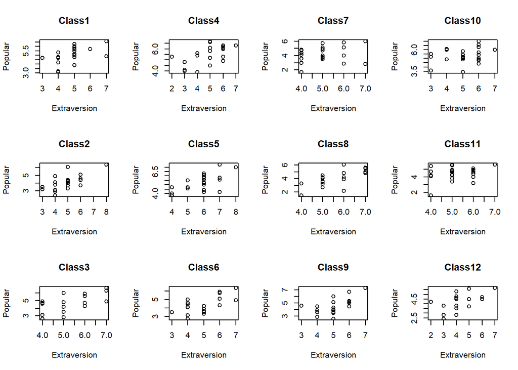

```r
layout(matrix(1:12, nrow = 3, ncol = 4))
for(i in 1:12){
  plot(get(paste("Class",i,sep=""))$Extraversion,
       get(paste("Class",i,sep=""))$Popular,
       main = paste("Class",i,sep=""),
       xlab = "Extraversion",
       ylab = "Popular")
}
```

### 3.1.2 - `Gender` versus `Popular`

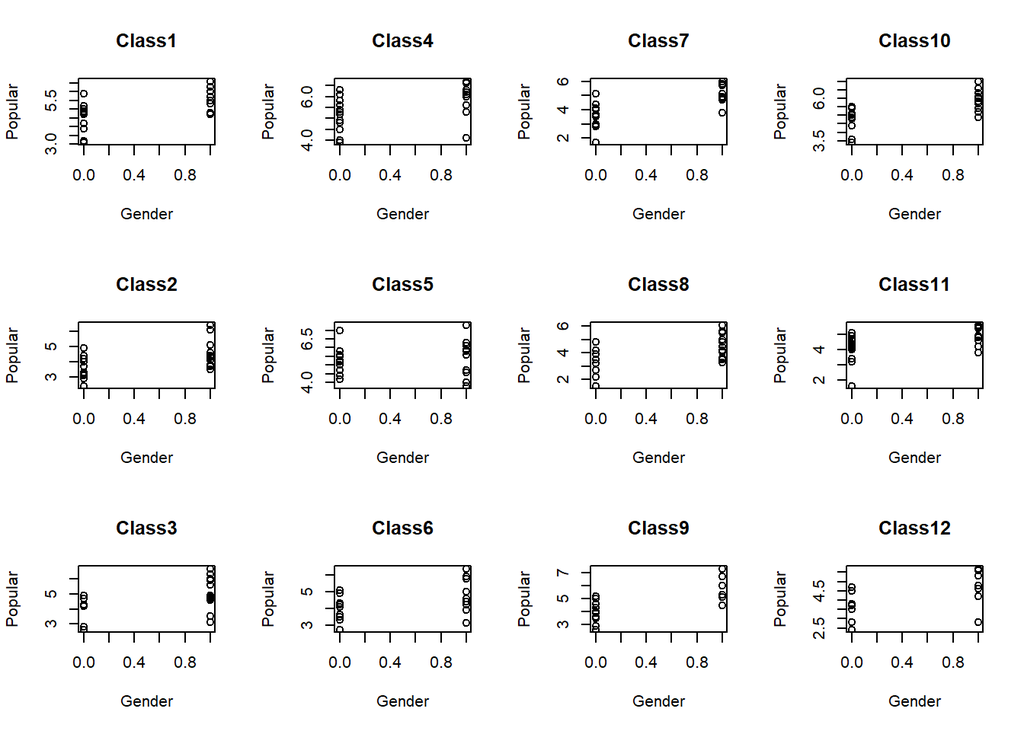

```r
layout(matrix(1:12, nrow = 3, ncol = 4))
for(i in 1:12){
  plot(get(paste("Class",i,sep=""))$Gender,
       get(paste("Class",i,sep=""))$Popular,
       main = paste("Class",i,sep=""),
       xlab = "Gender",
       ylab = "Popular")
}
```

### 3.1.3 - `Gender` versus `Extraversion`

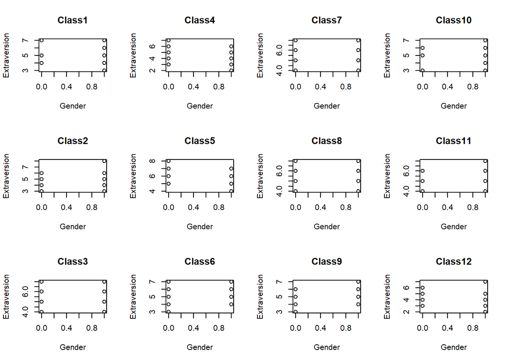

```r
layout(matrix(1:12, nrow = 3, ncol = 4))
for(i in 1:12){
  plot(get(paste("Class",i,sep=""))$Gender,
       get(paste("Class",i,sep=""))$Extraversion,
       main = paste("Class",i,sep=""),
       xlab = "Gender",
       ylab = "Extraversion")
}
```

### 3.1.4 - Alternative using the `ggpairs` plots

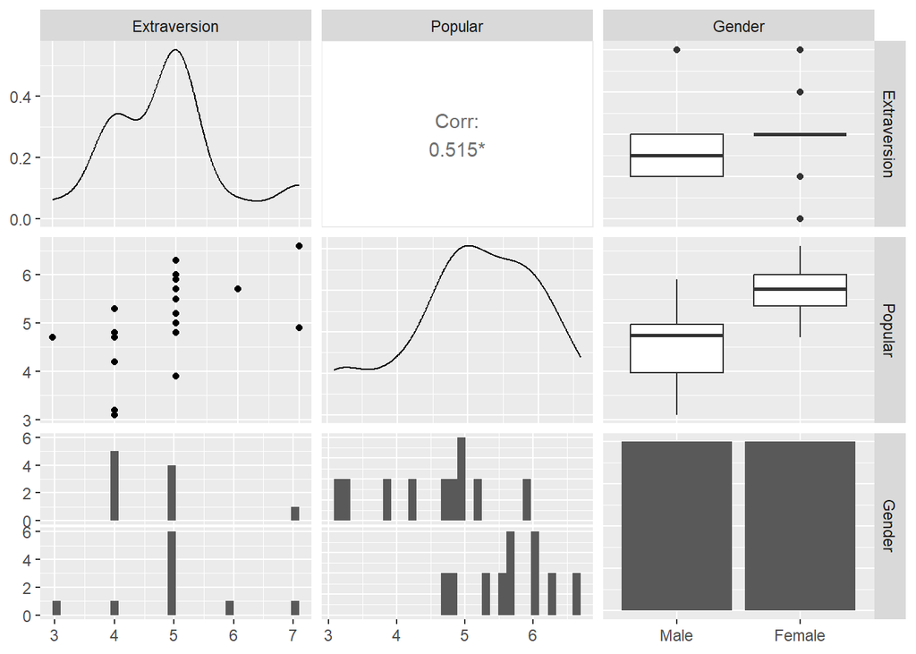

```r
subset_class1 <- Class1 %>%
                 select(Extraversion, Popular, Gender)
subset_class1 <- as_tibble(subset_class1)
subset_class1$Gender <- factor(subset_class1$Gender, labels = c("Male", "Female"))
ggpairs(subset_class1)
```

## 3.2 - Assignment 2: Regular regression analyses

Run regression analyses for each of the 12 classes separately using the `lm` command, and save the intercepts and regression coefficients of each of these analyses. In these analyses, use popularity as the dependent variable and `Extraversion` and `Gender` as independent variables. If needed as for instructions on using the lm command by typing `?lm` in R.

### 3.2.1 - Create empty coefficient matrix

```r
Coefficients <- matrix(NA, ncol = 3, nrow = 12)
colnames(Coefficients) <- c("Intercept", "Extraversion", "Gender")
```

### 3.2.2 - Automatically run the linear regression analyses for all classes

```r
for (i in 1:12) {
  Coefficients[i,] <- lm(Popular ~ 1+Extraversion+Gender,
                         data = Total[Total$Class==i,])$coefficients
}
Coefficients
```

```
      Intercept Extraversion    Gender
 [1,]  4.645688    0.4127072 1.0461878
 [2,]  3.840884    0.4837945 0.7481028
 [3,]  3.612967    0.7183673 1.4659864
 [4,]  5.227854    0.3537333 0.7951556
 [5,]  4.269324    0.7556751 0.8967710
 [6,]  3.964937    0.5818182 0.8300000
 [7,]  3.588881    0.1383459 1.4466165
 [8,]  2.953686    0.7918072 1.1672289
 [9,]  4.083984    0.4858407 1.4123894
[10,]  4.796733    0.1734940 1.0377510
[11,]  4.016614    0.2801310 0.8689956
[12,]  4.139235    0.4713801 1.0154977
```

We can see that there are quite some differences between classes in intercepts, regression coefficients of Extraversion, and regression coefficients of Gender. We can’t test these differences for significance however or predict them using class characteristics (this would require multilevel analysis). They are purely descriptive.

## 3.3 - Assignment 3: Regular regression analyses

Why can’t we include teacher experience as a predictor in the separate regression analyses above?

Because the scores on teacher experience don’t vary within classes. To look at the effect of the class level predictor teacher experience, we need save the mean popularity score of each class and the teacher experience scores.

## 3.4 - Assignment 4: Modeling average popularity

Save the mean popularity score of each class and the teacher experience scores. Subsequently, run a regression in which we predict the mean popularity using teacher experience and save the intercept and regression coefficient again. What is the sample size in this analysis?

### 3.4.1 - Create empty mean matrix

```r
Mean <- matrix(NA, ncol = 2, nrow = 12)
colnames(Mean) <- c("Popular", "TeacherExperience")
```

### 3.4.2 - Automatically obtain means for all classes

```r
for (i in 1:12) {
  Mean[i, 1] <- mean(eval(parse(text = paste("Class", i, sep = "")))$Popular)
  Mean[i, 2] <- mean(eval(parse(text = paste("Class", i, sep = "")))$teacherExp)
}
Mean <- as.data.frame(Mean)
```

### 3.4.3 - Run regression on the means

```r
ResultsLevel2 <- lm(Mean[,1]~1+Mean[,2]) # or
ResultsLevel2 <- lm(Mean$Popular ~ 1+ Mean$TeacherExperience)
summary(ResultsLevel2)
```

```
Call:
lm(formula = Mean$Popular ~ 1 + Mean$TeacherExperience)

Residuals:
     Min       1Q   Median       3Q      Max
-0.61470 -0.50580 -0.01702  0.25036  0.88791

Coefficients:
                       Estimate Std. Error t value Pr(>|t|)
(Intercept)             4.26431    0.41982  10.157 1.38e-06 ***
Mean$TeacherExperience  0.02670    0.02767   0.965    0.357
---
Signif. codes:  0 '***' 0.001 '**' 0.01 '*' 0.05 '.' 0.1 ' ' 1

Residual standard error: 0.5204 on 10 degrees of freedom
Multiple R-squared:  0.08516,   Adjusted R-squared:  -0.006324
F-statistic: 0.9309 on 1 and 10 DF,  p-value: 0.3574
```

The sample size is equal to the number of classes; that is, 12. There appears to be no effect of teacher experience on popularity.

## 3.5 - Assignment 5: Modeling average popularity

Run a multilevel analysis in which you regress `Popular` on `Gender` and `Extraversion` and you allow for between-class variance in the intercepts. Use the `lmer` function. For help, open `?lmer`(note that you will learn more details about the multilevel analysis code in the next days). - Compare the intercept and regression coefficients of Gender and Extraversion from the multilevel analysis to the average estimates across the 12 separate analyses. Are they the same? Why/Why not? - What about the multilevel regression coefficient for `teacherExp`? Is it the same as in the regression analysis you ran on the mean popularity and mean `teacherExp` scores? Why/Why not?

### 3.5.1 - Run the multilevel model

```r
ResultsLmer_Gender_Ex <- lmer(Popular ~ 1 + Gender + Extraversion + (1 | Class),
                              data = Total)
summary(ResultsLmer_Gender_Ex)
```

```
Linear mixed model fit by REML. t-tests use Satterthwaite's method ['lmerModLmerTest']
Formula: Popular ~ 1 + Gender + Extraversion + (1 | Class)
   Data: Total

REML criterion at convergence: 559

Scaled residuals:
     Min       1Q   Median       3Q      Max
-2.72798 -0.63053  0.07299  0.69288  2.43172

Random effects:
 Groups   Name        Variance Std.Dev.
 Class    (Intercept) 0.2756   0.5250
 Residual             0.4896   0.6997
Number of obs: 246, groups:  Class, 12

Fixed effects:
              Estimate Std. Error        df t value Pr(>|t|)
(Intercept)    4.16190    0.16389  12.79664   25.39 2.49e-12 ***
Gender         1.01018    0.09016 232.83079   11.21  < 2e-16 ***
Extraversion   0.46488    0.04246 236.22429   10.95  < 2e-16 ***
---
Signif. codes:  0 '***' 0.001 '**' 0.01 '*' 0.05 '.' 0.1 ' ' 1

Correlation of Fixed Effects:
            (Intr) Gender
Gender      -0.265
Extraversin  0.010 -0.029
```

### 3.5.2 - Compute mean intercepts and slopes for the 12 regular regression analyses

```r
apply(Coefficients, 2, mean, na.rm = TRUE)
```

```
   Intercept Extraversion       Gender
   4.0950657    0.4705912    1.0608902
```

### 3.5.3 - Run the multilevel model

```r
ResultsLmer_Gender_Ex <- lmer(Popular ~ 1 + Gender + Extraversion + (1 | Class),
                              data = Total)
summary(ResultsLmer_Gender_Ex)
```

```
Linear mixed model fit by REML. t-tests use Satterthwaite's method ['lmerModLmerTest']
Formula: Popular ~ 1 + Gender + Extraversion + (1 | Class)
   Data: Total

REML criterion at convergence: 559

Scaled residuals:
     Min       1Q   Median       3Q      Max
-2.72798 -0.63053  0.07299  0.69288  2.43172

Random effects:
 Groups   Name        Variance Std.Dev.
 Class    (Intercept) 0.2756   0.5250
 Residual             0.4896   0.6997
Number of obs: 246, groups:  Class, 12

Fixed effects:
              Estimate Std. Error        df t value Pr(>|t|)
(Intercept)    4.16190    0.16389  12.79664   25.39 2.49e-12 ***
Gender         1.01018    0.09016 232.83079   11.21  < 2e-16 ***
Extraversion   0.46488    0.04246 236.22429   10.95  < 2e-16 ***
---
Signif. codes:  0 '***' 0.001 '**' 0.01 '*' 0.05 '.' 0.1 ' ' 1

Correlation of Fixed Effects:
            (Intr) Gender
Gender      -0.265
Extraversin  0.010 -0.029
```

### 3.5.4 - Run the multilevel model `Gender` and `Extraversion`

```r
ResultsLmer_Gender_Ex <- lmer(Popular ~ 1 + Gender + Extraversion + (1 | Class),
                              data = Total)
summary(ResultsLmer_Gender_Ex)
```

```
Linear mixed model fit by REML. t-tests use Satterthwaite's method ['lmerModLmerTest']
Formula: Popular ~ 1 + Gender + Extraversion + (1 | Class)
   Data: Total

REML criterion at convergence: 559

Scaled residuals:
     Min       1Q   Median       3Q      Max
-2.72798 -0.63053  0.07299  0.69288  2.43172

Random effects:
 Groups   Name        Variance Std.Dev.
 Class    (Intercept) 0.2756   0.5250
 Residual             0.4896   0.6997
Number of obs: 246, groups:  Class, 12

Fixed effects:
              Estimate Std. Error        df t value Pr(>|t|)
(Intercept)    4.16190    0.16389  12.79664   25.39 2.49e-12 ***
Gender         1.01018    0.09016 232.83079   11.21  < 2e-16 ***
Extraversion   0.46488    0.04246 236.22429   10.95  < 2e-16 ***
---
Signif. codes:  0 '***' 0.001 '**' 0.01 '*' 0.05 '.' 0.1 ' ' 1

Correlation of Fixed Effects:
            (Intr) Gender
Gender      -0.265
Extraversin  0.010 -0.029
```

You see that the mean estimates across the separate analyses are not identical to the multilevel estimates. This is because multilevel analysis assumes that the inter-class differences in the intercept and coefficients are normally distributed, whereas the estimates from the separate analyses don’t impose a distribution on the individual estimates. As a result, the multilevel estimates are ‘pulled’ towards the mean parameter values across classes.

### 3.5.5 - Run the multilevel model with `teacherExp`

```r
ResultsLmer_teacherExp <- lmer(Popular ~ 1 + teacherExp + (1 | Class), Total)

summary(ResultsLmer_teacherExp)
```

```
Linear mixed model fit by REML. t-tests use Satterthwaite's method ['lmerModLmerTest']
Formula: Popular ~ 1 + teacherExp + (1 | Class)
   Data: Total

REML criterion at convergence: 727.8

Scaled residuals:
     Min       1Q   Median       3Q      Max
-2.83813 -0.58802  0.00534  0.65973  2.64678

Random effects:
 Groups   Name        Variance Std.Dev.
 Class    (Intercept) 0.2231   0.4723
 Residual             1.0165   1.0082
Number of obs: 246, groups:  Class, 12

Fixed effects:
            Estimate Std. Error       df t value Pr(>|t|)
(Intercept)  4.26224    0.42096 10.02133  10.125 1.39e-06 ***
teacherExp   0.02712    0.02771  9.96122   0.979    0.351
---
Signif. codes:  0 '***' 0.001 '**' 0.01 '*' 0.05 '.' 0.1 ' ' 1

Correlation of Fixed Effects:
           (Intr)
teacherExp -0.934
```

```r
summary(ResultsLevel2)
```

```
Call:
lm(formula = Mean$Popular ~ 1 + Mean$TeacherExperience)

Residuals:
     Min       1Q   Median       3Q      Max
-0.61470 -0.50580 -0.01702  0.25036  0.88791

Coefficients:
                       Estimate Std. Error t value Pr(>|t|)
(Intercept)             4.26431    0.41982  10.157 1.38e-06 ***
Mean$TeacherExperience  0.02670    0.02767   0.965    0.357
---
Signif. codes:  0 '***' 0.001 '**' 0.01 '*' 0.05 '.' 0.1 ' ' 1

Residual standard error: 0.5204 on 10 degrees of freedom
Multiple R-squared:  0.08516,   Adjusted R-squared:  -0.006324
F-statistic: 0.9309 on 1 and 10 DF,  p-value: 0.3574
```

The estimate for the effect of teacher Exp is not exactly the same. This is because the classes are not all the same size. Some have more pupils than others. The multilevel estimates are weighted for these class-size differences, while the regression analysis on the mean scores was not.